# Project #5 Artificial intelligance (Phase 2)

# (spring 2022)

```
Amirmahdi Ansaripour

Student ID: 810198358
```

Aproach :

Building a Feed-Forward Neural Network with Keras library to detect alphabet images.

```python
import pandas as pds
from sklearn.model_selection import train_test_split
import matplotlib.pyplot as plot
import numpy as np
import collections
from sklearn.preprocessing import LabelEncoder
import gc
import copy
import tensorflow.keras as API
from tensorflow.keras import layers
from sklearn.metrics import classification_report
categoricalLosFunction = 'categorical_crossentropy'
mseLosFunction = "mean_squared_error"
metric = ['accuracy']
BATCHSIZE = 32
firstLayerNuerons = 32
secondLayerNuerons = 32
testRatio = 0.7
lRate = 0.01
numberOfEpoches = 10
df = pds.read_csv("../input/az-handwritten-alphabets-in-csv-format/A_Z Handwritten Data.csv")
```

### Data Visualization and Pre-processing

- Displaying one sample of each class
- Dividing into train and test sets
- Reshaping all images to a fixed scale
- Showing the percentage of each label
- Normalizing colors to the $\{ 0, 1 \}$ interval
- One-hot encoding

```python
labels = df.iloc[:,0]
images = df.iloc[:, 1:]
```

```
Label : A
```

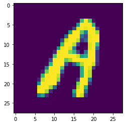

```
Label : B
```

[figure not shown]

```
Label : C
```

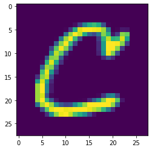

```
Label : D
```

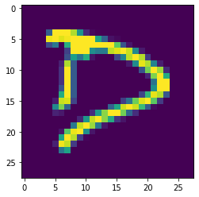

```
Label : E
```

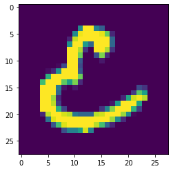

```
Label : F
```

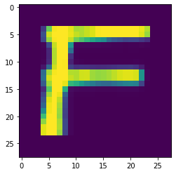

```
Label : G
```

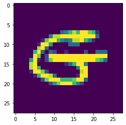

```
Label : H
```

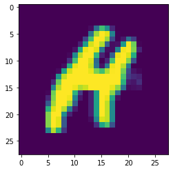

```
Label : I
```

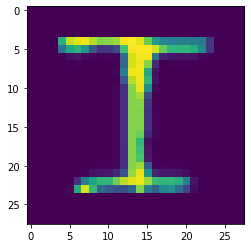

```
Label : J
```

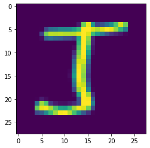

```
Label : K
```

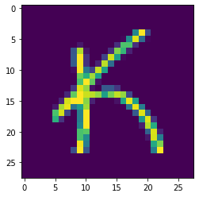

```
Label : L
```

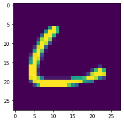

```
Label : M
```

[14 more figures not shown]

```
76698
```

```python
def showImageFromTrain(image):
    plot.figure(0)
    image2 = np.array(image)
    image2 = image2.reshape(28, 28)
#     unique, counts = np.unique(data[0], return_counts = True)
#     print("Unique values and their frequency in the picture : ")
#     print(np.asarray((unique, counts)).T)
    plot.imshow(image2)
    plot.show()
    del image
    del image2
    return


def showImageFromAllClasses(images, label):
    for i in range(0, 26):
        for j in range(len(label)):
            if(label[j] == i):
                print("Label : " + chr(65 + i))
                showImageFromTrain(images.iloc[j])
                break
    return

showImageFromAllClasses(images, labels)
gc.collect()
```

```python
print("Number of images (data) read : " + str(len(images)))
charLabel = ['a'] * len(labels)
for i in range(len(labels)):
    a = 65 + labels[i]
    charLabel[i] = chr(a)
gc.collect()
collections.Counter(charLabel)
# print(labels.value_counts().sort_index())
```

```
Number of images (data) read : 372450
```

```
Counter({'A': 13869,
         'B': 8668,
         'C': 23409,
         'D': 10134,
         'E': 11440,
         'F': 1163,
         'G': 5762,
         'H': 7218,
         'I': 1120,
         'J': 8493,
         'K': 5603,
         'L': 11586,
         'M': 12336,
         'N': 19010,
         'O': 57825,
         'P': 19341,
         'Q': 5812,
         'R': 11566,
         'S': 48419,
         'T': 22495,
         'U': 29008,
         'V': 4182,
         'W': 10784,
         'X': 6272,
         'Y': 10859,
         'Z': 6076})
```

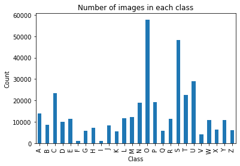

```
5799
```

```python
def showFreqs(test, titl):
    df = pds.DataFrame({'freq': test})
    df.groupby('freq').size().plot(kind='bar')
    plot.xlabel("Class")
    plot.ylabel("Count")
    plot.title(titl)
    plot.show()
    return

showFreqs(charLabel, "Number of images in each class")
del charLabel
gc.collect()
# showFreqs(labels)
```

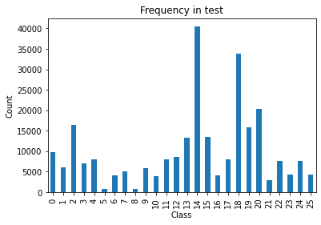

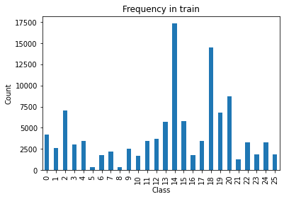

```
11829
```

```python
def normalize(train):
    train = train / 255
    return train

def divideToTrainandTest(trainDataFrame, label, ratio):

    X_train, X_test, y_train, y_test = train_test_split(trainDataFrame, label,
   stratify = LabelEncoder().fit_transform(label),
    test_size = ratio, random_state=0)

    return X_train, X_test, y_train, y_test


X_train, X_test, y_train, y_test = divideToTrainandTest(images, labels, testRatio)
X_train = normalize(X_train)
X_test = normalize(X_test)
testData = (X_test, y_test)
# print("shape " + str(X_train.iloc[0].shape))
del df

showFreqs(y_test, "Frequency in test")
showFreqs(y_train, "Frequency in train")

gc.collect()
# print(X_train.shape)
# print(X_test.shape)
```

Why did we normalize the pixcels?

Because when wieghts are being updated, for example $x_1 = 0, x_2 = 255$, the new value $(w_1x_1 + w_2x_2)$ will be biased to $x_2$ value.

### Onehot method

One-hot encoding is a famous technique in classification cases which the labels don't any priority to each other; In other words, all classes should be treated equally. Without one-hot, the weights will be biased towards predicting last alphabets because of their high index (A = 0 , Z = 25). However, the index of letters should not affect the classification.

```python
def oneHot(labels):
    array = np.array(labels)
    oneHotted = np.zeros((len(labels), 26))
    oneHotted[np.arange(array.size),array] = 1
#     print(labels.iloc[0])
#     print(oneHotted[0])
    return oneHotted
print("Tenth train sample is : " + str(y_train.iloc[10]))
print("Tenth test sample is : " + str(y_test.iloc[10]))
tempYTrain = copy.deepcopy(y_train)
tempYTest = copy.deepcopy(y_test)
y_train = oneHot(tempYTrain)
y_test = oneHot(tempYTest)
del tempYTrain
del tempYTest
gc.collect()
print("One hotted tenth train sample : ")
print(y_train[10])
print("One hotted tenth test sample : ")
print(y_test[10])
```

```
Tenth train sample is : 14
Tenth test sample is : 13
One hotted tenth train sample :
[0. 0. 0. 0. 0. 0. 0. 0. 0. 0. 0. 0. 0. 0. 1. 0. 0. 0. 0. 0. 0. 0. 0. 0.
 0. 0.]
One hotted tenth test sample :
[0. 0. 0. 0. 0. 0. 0. 0. 0. 0. 0. 0. 0. 1. 0. 0. 0. 0. 0. 0. 0. 0. 0. 0.
 0. 0.]
```

```python
def printClassificationReport(model ,X, y, Set):
    modelPred = model.predict(X)
    maxYIndex = np.argmax(y, 1)
    maxYPredIndex = np.argmax(modelPred, 1)
    print("classification parameters on " + Set)
    print(classification_report(y_true = maxYIndex, y_pred = maxYPredIndex))
    return

def plotAccuracyandLoss(epochs, state):
    plot.figure(figsize=(10, 10))
    plot.plot(epochs.history['loss'], color = 'y')
    plot.plot(epochs.history['accuracy'], color = 'r')
    plot.plot(epochs.history['val_loss'], color = 'b')
    plot.plot(epochs.history['val_accuracy'], color = 'g')

    plot.title('Loss and Accuracy for ' + state)
    plot.ylabel('Loss/Accuracy')
    plot.xlabel('Epoch')
    plot.legend(['train loss', 'train accuracy', 'test loss', 'test accuracy'], loc=(1.01,0))
    plot.show()
    gc.collect()
    return
```

```python
def analyzeModule(network1, Optimizer, losFunction, state, numberofepochs):
    network1.compile(optimizer = Optimizer, loss = losFunction, metrics = metric)
    network1.summary()
    print(state + '\n\n')
    results = network1.fit(X_train, y_train, batch_size = BATCHSIZE, validation_data = (X_test, y_test), epochs = numberofepochs)
    plotAccuracyandLoss(results, state)
    printClassificationReport(network1 ,X_train, y_train, "train for a " + state)
    printClassificationReport(network1 ,X_test, y_test, "test for a " + state)
    print("******************************************************************************************")
    print("******************************************************************************************")
    print("\n\n")
    gc.collect()
    return
```

```python
def feedForwardNeuralNetwork(firstL_nuerons, secondL_nuerons, numberofepoches,
                              function,imageShape = X_train.iloc[0].shape, regularizer = None):
    inputLayer = API.layers.Input(imageShape)
    outputLayer = API.layers.Flatten()(inputLayer)
    outputLayer = API.layers.Dense(firstL_nuerons, activation = function, kernel_regularizer = regularizer)(outputLayer)
    outputLayer = API.layers.Dense(secondL_nuerons, activation = function, kernel_regularizer = regularizer)(outputLayer)
    outputLayer = API.layers.Dense(26, activation = "softmax", kernel_regularizer = regularizer)(outputLayer)

    network = API.Model(inputLayer, outputLayer)
    del inputLayer
    del outputLayer
    gc.collect()
    return network
```

### Neural Network Architecture

As seen in the scheme below, the input images are first flatten, then given to a network having two hidden layers. Finally, the soft-max function decides which label has got the highest likelihood.

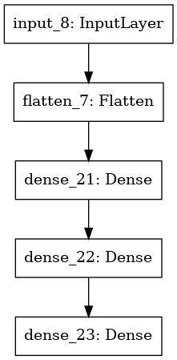

```python
network1 = feedForwardNeuralNetwork(firstLayerNuerons, secondLayerNuerons, numberofepoches = 5,function = 'relu')
API.utils.plot_model(network1)
```

```
2022-06-20 05:46:09.909574: I tensorflow/core/common_runtime/process_util.cc:146] Creating new thread pool with default inter op setting: 2. Tune using inter_op_parallelism_threads for best performance.
```

```
Model: "model"
_________________________________________________________________
Layer (type)                 Output Shape              Param #
=================================================================
input_1 (InputLayer)         [(None, 784)]             0
_________________________________________________________________
flatten (Flatten)            (None, 784)               0
_________________________________________________________________
dense (Dense)                (None, 32)                25120
_________________________________________________________________
dense_1 (Dense)              (None, 32)                1056
_________________________________________________________________
dense_2 (Dense)              (None, 26)                858
=================================================================
Total params: 27,034
Trainable params: 27,034
Non-trainable params: 0
_________________________________________________________________
a network with momentum = 0
```

```
2022-06-20 05:46:11.458560: I tensorflow/compiler/mlir/mlir_graph_optimization_pass.cc:185] None of the MLIR Optimization Passes are enabled (registered 2)
```

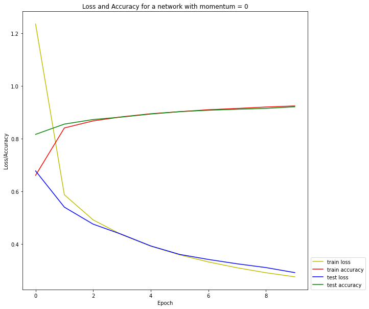

```
classification parameters on train for a a network with momentum = 0
              precision    recall  f1-score   support

           0       0.93      0.89      0.91      4161
           1       0.93      0.85      0.89      2600
           2       0.94      0.96      0.95      7023
           3       0.88      0.85      0.86      3040
           4       0.91      0.88      0.89      3432
           5       0.91      0.86      0.88       349
           6       0.84      0.86      0.85      1729
           7       0.85      0.83      0.84      2165
           8       0.93      0.79      0.85       336
           9       0.85      0.88      0.87      2548
          10       0.86      0.79      0.83      1681
          11       0.93      0.96      0.94      3476
```

[output cut: 52 more lines]

```
0
```

```python
analyzeModule(network1, API.optimizers.SGD(lRate, 0), categoricalLosFunction, "a network with momentum = 0", 10)
# del network1
```

### Momentum and its rule

Momentum is a term added to gradient descent to manage the procedure of updating the weights. Since momentum formla has a recursive format, the updating rule depends on the previous weights.

As the momentum parameter gets higher, the dependency increases and if the network gets stucks in a local optima, it won't get rid of it easily.

$$w_{t+1} = w_t - \alpha m_t$$$$m_t = \beta m_{t-1} + (1 - \beta)[\frac{\partial L}{\partial w_t}]$$

$\alpha$ is the learning rate, and $\beta$ is the momentum value.

```
Model: "model_2"
_________________________________________________________________
Layer (type)                 Output Shape              Param #
=================================================================
input_3 (InputLayer)         [(None, 784)]             0
_________________________________________________________________
flatten_2 (Flatten)          (None, 784)               0
_________________________________________________________________
dense_6 (Dense)              (None, 32)                25120
_________________________________________________________________
dense_7 (Dense)              (None, 32)                1056
_________________________________________________________________
dense_8 (Dense)              (None, 26)                858
=================================================================
Total params: 27,034
Trainable params: 27,034
Non-trainable params: 0
_________________________________________________________________
a network with momemtum = 0.5
```

```
2022-06-20 13:31:48.779032: I tensorflow/compiler/mlir/mlir_graph_optimization_pass.cc:185] None of the MLIR Optimization Passes are enabled (registered 2)
```

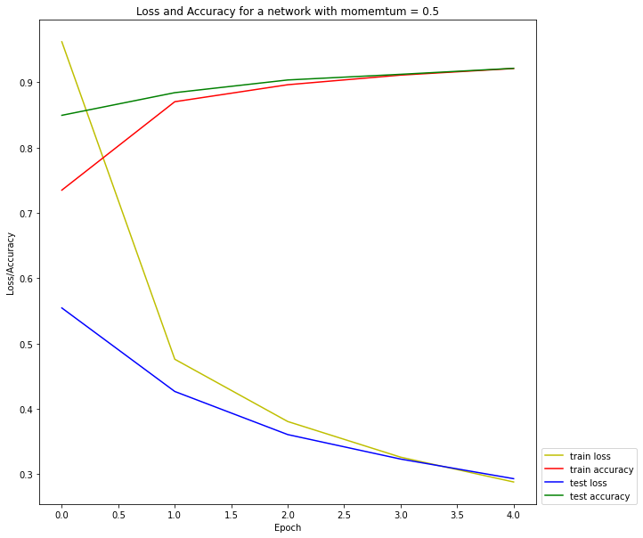

```
classification parameters on train for a a network with momemtum = 0.5
              precision    recall  f1-score   support

           0       0.84      0.94      0.89      4161
           1       0.92      0.87      0.89      2600
           2       0.93      0.96      0.94      7023
           3       0.88      0.86      0.87      3040
           4       0.94      0.83      0.89      3432
           5       0.88      0.85      0.87       349
           6       0.75      0.88      0.81      1729
           7       0.89      0.81      0.85      2165
           8       0.94      0.78      0.85       336
           9       0.85      0.92      0.88      2548
          10       0.75      0.88      0.81      1681
          11       0.95      0.94      0.95      3476
```

[output cut: 52 more lines]

```python
analyzeModule(network1, API.optimizers.SGD(lRate, 0.5), categoricalLosFunction, "a network with momemtum = 0.5", 5)
```

```
Model: "model_2"
_________________________________________________________________
Layer (type)                 Output Shape              Param #
=================================================================
input_3 (InputLayer)         [(None, 784)]             0
_________________________________________________________________
flatten_2 (Flatten)          (None, 784)               0
_________________________________________________________________
dense_6 (Dense)              (None, 32)                25120
_________________________________________________________________
dense_7 (Dense)              (None, 32)                1056
_________________________________________________________________
dense_8 (Dense)              (None, 26)                858
=================================================================
Total params: 27,034
Trainable params: 27,034
Non-trainable params: 0
_________________________________________________________________
a network with momentum = 0.9
```

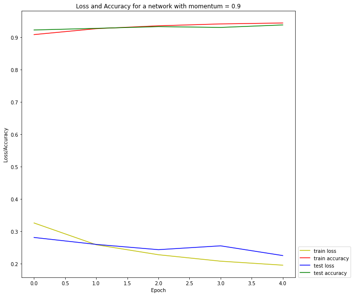

```
classification parameters on train for a a network with momentum = 0.9
              precision    recall  f1-score   support

           0       0.91      0.97      0.94      4161
           1       0.93      0.92      0.92      2600
           2       0.93      0.98      0.95      7023
           3       0.88      0.90      0.89      3040
           4       0.97      0.86      0.91      3432
           5       0.94      0.91      0.92       349
           6       0.83      0.91      0.87      1729
           7       0.93      0.87      0.90      2165
           8       0.95      0.87      0.91       336
           9       0.87      0.95      0.91      2548
          10       0.94      0.87      0.90      1681
          11       0.95      0.97      0.96      3476
```

[output cut: 52 more lines]

```python
analyzeModule(network1, API.optimizers.SGD(lRate, 0.9), categoricalLosFunction, "a network with momentum = 0.9", 5)
```

```
Model: "model_2"
_________________________________________________________________
Layer (type)                 Output Shape              Param #
=================================================================
input_3 (InputLayer)         [(None, 784)]             0
_________________________________________________________________
flatten_2 (Flatten)          (None, 784)               0
_________________________________________________________________
dense_6 (Dense)              (None, 32)                25120
_________________________________________________________________
dense_7 (Dense)              (None, 32)                1056
_________________________________________________________________
dense_8 (Dense)              (None, 26)                858
=================================================================
Total params: 27,034
Trainable params: 27,034
Non-trainable params: 0
_________________________________________________________________
a network with momentum = 0.98
```

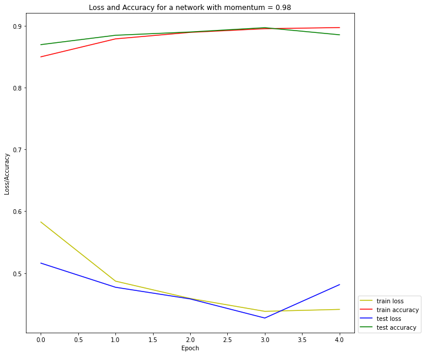

```
classification parameters on train for a a network with momentum = 0.98
              precision    recall  f1-score   support

           0       0.78      0.92      0.84      4161
           1       0.53      0.85      0.66      2600
           2       0.93      0.92      0.93      7023
           3       0.83      0.84      0.83      3040
           4       0.84      0.87      0.85      3432
           5       0.85      0.75      0.80       349
           6       0.74      0.72      0.73      1729
           7       0.92      0.77      0.83      2165
           8       0.83      0.63      0.72       336
           9       0.88      0.78      0.83      2548
          10       0.74      0.87      0.80      1681
          11       0.89      0.95      0.92      3476
```

[output cut: 52 more lines]

```python
gc.collect()
analyzeModule(network1, API.optimizers.SGD(lRate, 0.98), categoricalLosFunction, "a network with momentum = 0.98", 5)
```

### Adam optimizer

Adam optimizer merges the momentum method and another method for controlling weights called $\textbf{Root Mean Square Propagation}$. It modifies the definitions of $m_t$ and $v_t$ in the following way:

$$\hat{m_t} = \frac{m_t}{1 - \beta_1^t} \;\; (Momentum)$$

$$\hat{v_t} = \frac{v_t}{1 - \beta_2^t} \;\; (RMSP)$$

$\beta_1$ and $\beta_2$ are hyper-parameters. Finally, the updating rule in each epoch becomes:

$$w_{t+1} = w_t - \hat{m_t}(\frac{\alpha}{\sqrt{\hat{v_t}} + \epsilon})$$

```
Model: "model_2"
_________________________________________________________________
Layer (type)                 Output Shape              Param #
=================================================================
input_3 (InputLayer)         [(None, 784)]             0
_________________________________________________________________
flatten_2 (Flatten)          (None, 784)               0
_________________________________________________________________
dense_6 (Dense)              (None, 32)                25120
_________________________________________________________________
dense_7 (Dense)              (None, 32)                1056
_________________________________________________________________
dense_8 (Dense)              (None, 26)                858
=================================================================
Total params: 27,034
Trainable params: 27,034
Non-trainable params: 0
_________________________________________________________________
a network with Adam Optimizer
```

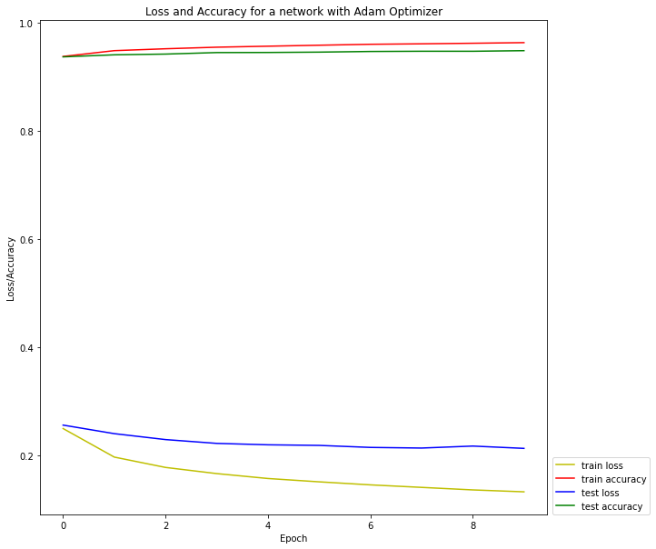

```
classification parameters on train for a a network with Adam Optimizer
              precision    recall  f1-score   support

           0       0.95      0.96      0.95      4161
           1       0.91      0.96      0.93      2600
           2       0.97      0.98      0.97      7023
           3       0.92      0.94      0.93      3040
           4       0.97      0.95      0.96      3432
           5       0.95      0.97      0.96       349
           6       0.94      0.89      0.92      1729
           7       0.94      0.90      0.92      2165
           8       0.93      0.92      0.93       336
           9       0.94      0.93      0.94      2548
          10       0.94      0.92      0.93      1681
          11       0.98      0.97      0.98      3476
```

[output cut: 52 more lines]

```python
gc.collect()
analyzeModule(network1, API.optimizers.Adam(), categoricalLosFunction, "a network with Adam Optimizer", 10)
```

### MSE loss function

```
Model: "model_6"
_________________________________________________________________
Layer (type)                 Output Shape              Param #
=================================================================
input_7 (InputLayer)         [(None, 784)]             0
_________________________________________________________________
flatten_6 (Flatten)          (None, 784)               0
_________________________________________________________________
dense_18 (Dense)             (None, 32)                25120
_________________________________________________________________
dense_19 (Dense)             (None, 32)                1056
_________________________________________________________________
dense_20 (Dense)             (None, 26)                858
=================================================================
Total params: 27,034
Trainable params: 27,034
Non-trainable params: 0
_________________________________________________________________
a network with mse loss function
```

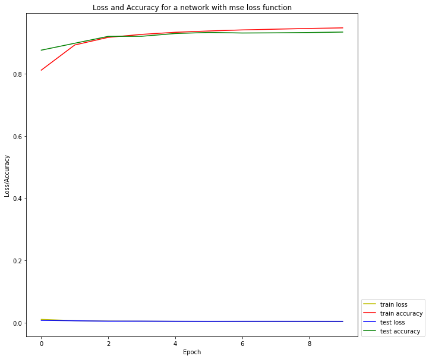

```
classification parameters on train for a a network with mse loss function
              precision    recall  f1-score   support

           0       0.94      0.94      0.94      4161
           1       0.95      0.90      0.92      2600
           2       0.98      0.94      0.96      7023
           3       0.90      0.92      0.91      3040
           4       0.86      0.94      0.89      3432
           5       0.00      0.00      0.00       349
           6       0.94      0.86      0.90      1729
           7       0.81      0.91      0.86      2165
           8       0.99      0.82      0.90       336
           9       0.92      0.94      0.93      2548
          10       0.92      0.89      0.90      1681
          11       0.92      0.98      0.95      3476
```

[output cut: 18 more lines]

```
classification parameters on test for a a network with mse loss function
```

```
              precision    recall  f1-score   support

           0       0.93      0.93      0.93      9708
           1       0.93      0.86      0.90      6068
           2       0.97      0.93      0.95     16386
           3       0.87      0.89      0.88      7094
           4       0.83      0.92      0.87      8008
           5       0.00      0.00      0.00       814
           6       0.92      0.86      0.89      4033
           7       0.79      0.89      0.84      5053
           8       0.98      0.77      0.86       784
           9       0.89      0.92      0.91      5945
          10       0.88      0.84      0.86      3922
          11       0.91      0.97      0.94      8110
          12       0.96      0.91      0.93      8635
```

[output cut: 17 more lines]

```python
network2 = feedForwardNeuralNetwork(firstLayerNuerons, secondLayerNuerons, numberofepoches = 10, function = 'relu')
analyzeModule(network2, API.optimizers.Adam(), mseLosFunction, "a network with mse loss function", 10)
```

### Number of epochs

Low epoch number leads to underfitting, and extremely high values lead to overfitting. Both of them are undesirable.

```
Model: "model_3"
_________________________________________________________________
Layer (type)                 Output Shape              Param #
=================================================================
input_4 (InputLayer)         [(None, 784)]             0
_________________________________________________________________
flatten_3 (Flatten)          (None, 784)               0
_________________________________________________________________
dense_9 (Dense)              (None, 32)                25120
_________________________________________________________________
dense_10 (Dense)             (None, 32)                1056
_________________________________________________________________
dense_11 (Dense)             (None, 26)                858
=================================================================
Total params: 27,034
Trainable params: 27,034
Non-trainable params: 0
_________________________________________________________________
a network with 20 epochs
```

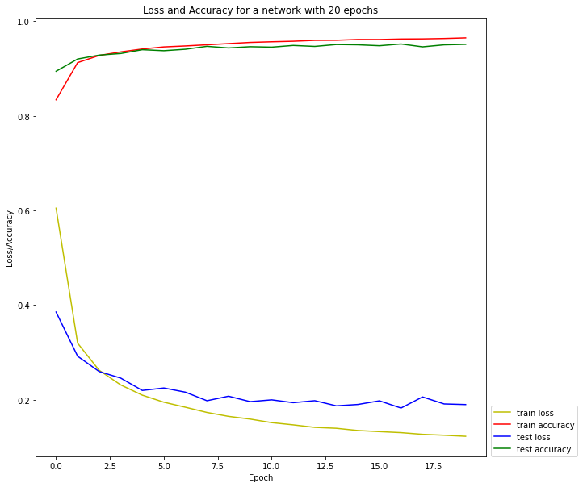

```
classification parameters on train for a a network with 20 epochs
              precision    recall  f1-score   support

           0       0.96      0.96      0.96      4161
           1       0.91      0.97      0.94      2600
           2       0.98      0.97      0.98      7023
           3       0.93      0.94      0.93      3040
           4       0.95      0.96      0.96      3432
           5       0.93      0.95      0.94       349
           6       0.96      0.92      0.94      1729
           7       0.94      0.91      0.93      2165
           8       0.96      0.88      0.92       336
           9       0.96      0.93      0.95      2548
          10       0.96      0.93      0.94      1681
          11       0.98      0.97      0.97      3476
```

[output cut: 52 more lines]

```python
gc.collect()
network2 = feedForwardNeuralNetwork(firstLayerNuerons, secondLayerNuerons, numberofepoches = 20, function = 'relu')
gc.collect()
analyzeModule(network2, API.optimizers.Adam(), categoricalLosFunction, "a network with 20 epochs", 20)
```

### L2 regularizer

L1 and L2 regularizers are used to prevent the model's weights from getting high values, making the model complicated.

$$L = \Sigma_{i=1}^n (- y_i log(\hat{y_i})) + L \Sigma w^2$$

Where $w$ s are the network's weights.

```
2022-06-20 15:08:43.355541: I tensorflow/core/common_runtime/process_util.cc:146] Creating new thread pool with default inter op setting: 2. Tune using inter_op_parallelism_threads for best performance.
```

```
Model: "model"
_________________________________________________________________
Layer (type)                 Output Shape              Param #
=================================================================
input_1 (InputLayer)         [(None, 784)]             0
_________________________________________________________________
flatten (Flatten)            (None, 784)               0
_________________________________________________________________
dense (Dense)                (None, 32)                25120
_________________________________________________________________
dense_1 (Dense)              (None, 32)                1056
_________________________________________________________________
dense_2 (Dense)              (None, 26)                858
=================================================================
Total params: 27,034
Trainable params: 27,034
Non-trainable params: 0
_________________________________________________________________
a network with L2 regularizer
```

```
2022-06-20 15:08:44.904071: I tensorflow/compiler/mlir/mlir_graph_optimization_pass.cc:185] None of the MLIR Optimization Passes are enabled (registered 2)
```

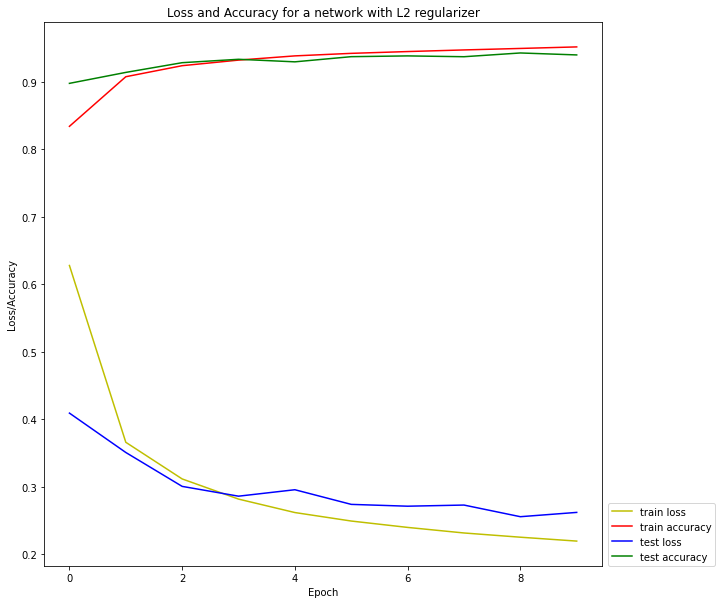

```
classification parameters on train for a a network with L2 regularizer
              precision    recall  f1-score   support

           0       0.94      0.96      0.95      4161
           1       0.89      0.94      0.91      2600
           2       0.98      0.95      0.96      7023
           3       0.80      0.95      0.87      3040
           4       0.97      0.89      0.93      3432
           5       0.95      0.88      0.91       349
           6       0.97      0.81      0.88      1729
           7       0.92      0.91      0.91      2165
           8       0.89      0.90      0.90       336
           9       0.97      0.87      0.92      2548
          10       0.89      0.91      0.90      1681
          11       0.94      0.98      0.96      3476
```

[output cut: 52 more lines]

```python
network3 = feedForwardNeuralNetwork(firstLayerNuerons, secondLayerNuerons, numberofepoches = 10,
                                    function = 'relu', regularizer = API.regularizers.l2(0.0001))
analyzeModule(network3, API.optimizers.Adam(), categoricalLosFunction, "a network with L2 regularizer", 10)
```

```python
# network3 = feedForwardNeuralNetwork(firstLayerNuerons, secondLayerNuerons, numberofepoches = 10,
#                                     function = 'relu', regularizer = API.regularizers.l2(0.1)) // the accuracy is very low
# analyzeModule(network3, API.optimizers.Adam(), categoricalLosFunction, "a network with L2 regularizer", 10)
```

```python
def feedForwardwithDropOut(firstL_nuerons, secondL_nuerons, numberofepoches, dropout,
                              function,imageShape = X_train.iloc[0].shape, regularizer = None):
    inputLayer = API.layers.Input(imageShape)
    outputLayer = API.layers.Flatten()(inputLayer)
    outputLayer = API.layers.Dense(firstL_nuerons, activation = function, kernel_regularizer = regularizer)(outputLayer)
    outputLayer = API.layers.Dropout(dropout)(outputLayer)
    outputLayer = API.layers.Dense(secondL_nuerons, activation = function, kernel_regularizer = regularizer)(outputLayer)
    outputLayer = API.layers.Dropout(dropout)(outputLayer)
    outputLayer = API.layers.Dense(26, activation = "softmax", kernel_regularizer = regularizer)(outputLayer)

    network = API.Model(inputLayer, outputLayer)
    del inputLayer
    del outputLayer
    gc.collect()
    return network
```

### Dropout regularizer

Dropping out is a technique used to neutralize some weights in a network in order to reduce complexity.

```
Model: "model_5"
_________________________________________________________________
Layer (type)                 Output Shape              Param #
=================================================================
input_6 (InputLayer)         [(None, 784)]             0
_________________________________________________________________
flatten_5 (Flatten)          (None, 784)               0
_________________________________________________________________
dense_15 (Dense)             (None, 32)                25120
_________________________________________________________________
dropout_6 (Dropout)          (None, 32)                0
_________________________________________________________________
dense_16 (Dense)             (None, 32)                1056
_________________________________________________________________
dropout_7 (Dropout)          (None, 32)                0
_________________________________________________________________
dense_17 (Dense)             (None, 26)                858
=================================================================
Total params: 27,034
Trainable params: 27,034
Non-trainable params: 0
_________________________________________________________________
a network with dropout value of 0.1
```

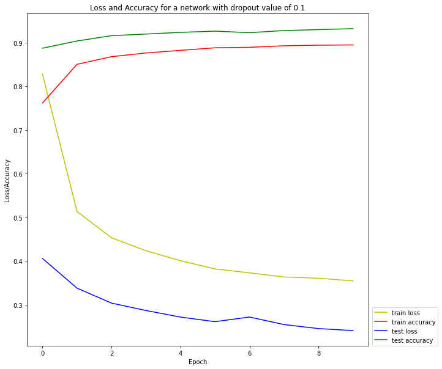

```
classification parameters on train for a a network with dropout value of 0.1
              precision    recall  f1-score   support

           0       0.90      0.94      0.92      4161
           1       0.91      0.92      0.91      2600
           2       0.96      0.96      0.96      7023
           3       0.86      0.90      0.88      3040
           4       0.93      0.91      0.92      3432
           5       0.93      0.89      0.91       349
           6       0.92      0.82      0.87      1729
           7       0.88      0.85      0.86      2165
           8       0.95      0.84      0.89       336
           9       0.93      0.86      0.89      2548
          10       0.83      0.89      0.86      1681
          11       0.94      0.97      0.96      3476
```

[output cut: 52 more lines]

```python
network3 = feedForwardwithDropOut(firstLayerNuerons, secondLayerNuerons, numberofepoches = 10, dropout = 0.1, function = 'relu')
analyzeModule(network3, API.optimizers.Adam(), categoricalLosFunction, "a network with dropout value of 0.1", 10)
```

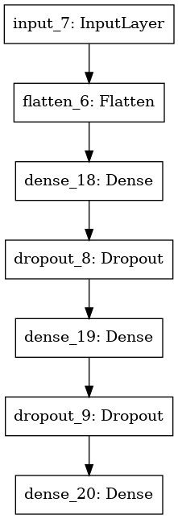

```python
API.utils.plot_model(network3)
```

### Conclusion

In this assignment, we learned how to flatten images and train a neural network on them. In addition, we analyzed how employing Adam optimizer, L2 regularizer, and choosing right values for epoch numbers and dropout rate can affect the network's output.

### Reference

1. https://keras.io/getting_started/intro_to_keras_for_engineers/
1. https://www.tutorialspoint.com/google_colab/index.htm
1. https://colab.research.google.com/notebooks/intro.ipynb
1. https://machinelearningmastery.com/introduction-to-regularization-to-reduce-overfitting-and-improve-generalization-error/